# Part I - Ford GoBike System Data Exploration

## Introduction

This analysis explores the Ford GoBike System dataset for February 2019. The dataset contains information about individual bike-sharing trips in the San Francisco Bay Area, including trip duration, start and end stations, user type, rider birth year, and gender. The main goal of this exploration is to understand typical trip behavior and investigate how trip duration varies across different types of riders, particularly Customers and Subscribers.

## Preliminary Wrangling

```python
# import all packages and set plots to be embedded inline
import numpy as np
import pandas as pd
import matplotlib.pyplot as plt
import seaborn as sns
```

```python
df = pd.read_csv('201902-fordgobike-tripdata - 201902-fordgobike-tripdata.csv')
df.shape
```

```
(183412, 16)
```

```python
df.info()
```

```
<class 'pandas.core.frame.DataFrame'>
RangeIndex: 183412 entries, 0 to 183411
Data columns (total 16 columns):
 #   Column                   Non-Null Count   Dtype
---  ------                   --------------   -----
 0   duration_sec             183412 non-null  int64
 1   start_time               183412 non-null  object
 2   end_time                 183412 non-null  object
 3   start_station_id         183215 non-null  float64
 4   start_station_name       183215 non-null  object
 5   start_station_latitude   183412 non-null  float64
 6   start_station_longitude  183412 non-null  float64
 7   end_station_id           183215 non-null  float64
 8   end_station_name         183215 non-null  object
 9   end_station_latitude     183412 non-null  float64
 10  end_station_longitude    183412 non-null  float64
 11  bike_id                  183412 non-null  int64
 12  user_type                183412 non-null  object
 13  member_birth_year        175147 non-null  float64
 14  member_gender            175147 non-null  object
 15  bike_share_for_all_trip  183412 non-null  object
dtypes: float64(7), int64(2), object(7)
memory usage: 22.4+ MB
```

```python
df.head()
```

|  | duration_sec | start_time | end_time | start_station_id | start_station_name | start_station_latitude | start_station_longitude | end_station_id | end_station_name | end_station_latitude | end_station_longitude | bike_id | user_type | member_birth_year | member_gender | bike_share_for_all_trip |
| --- | --- | --- | --- | --- | --- | --- | --- | --- | --- | --- | --- | --- | --- | --- | --- | --- |
| 0 | 52185 | 2019-02-28 17:32:10 | 2019-03-01 8:01:56 | 21.0 | Montgomery St BART Station (Market St at 2nd St) | 37.789625 | -122.400811 | 13.0 | Commercial St at Montgomery St | 37.794231 | -122.402923 | 4902 | Customer | 1984.0 | Male | No |
| 1 | 42521 | 2019-02-28 18:53:22 | 2019-03-01 6:42:03 | 23.0 | The Embarcadero at Steuart St | 37.791464 | -122.391034 | 81.0 | Berry St at 4th St | 37.775880 | -122.393170 | 2535 | Customer | NaN | NaN | No |
| 2 | 61854 | 2019-02-28 12:13:13 | 2019-03-01 5:24:08 | 86.0 | Market St at Dolores St | 37.769305 | -122.426826 | 3.0 | Powell St BART Station (Market St at 4th St) | 37.786375 | -122.404904 | 5905 | Customer | 1972.0 | Male | No |
| 3 | 36490 | 2019-02-28 17:54:26 | 2019-03-01 4:02:37 | 375.0 | Grove St at Masonic Ave | 37.774836 | -122.446546 | 70.0 | Central Ave at Fell St | 37.773311 | -122.444293 | 6638 | Subscriber | 1989.0 | Other | No |
| 4 | 1585 | 2019-02-28 23:54:19 | 2019-03-01 0:20:44 | 7.0 | Frank H Ogawa Plaza | 37.804562 | -122.271738 | 222.0 | 10th Ave at E 15th St | 37.792714 | -122.248780 | 4898 | Subscriber | 1974.0 | Male | Yes |

```python
df['member_birth_year'].describe()
```

```
count    175147.000000
mean       1984.806437
std          10.116689
min        1878.000000
25%        1980.000000
50%        1987.000000
75%        1992.000000
max        2001.000000
Name: member_birth_year, dtype: float64
```

```python
df[df['member_birth_year'] < 1920]['member_birth_year'].value_counts().sort_index()
```

```
member_birth_year
1878.0     1
1900.0    53
1901.0     6
1902.0    11
1910.0     1
Name: count, dtype: int64
```

### What is the structure of your dataset?

The dataset contains 183,412 Ford GoBike trips with 16 features. The features include trip duration, start and end times, station information and coordinates, bike ID, user type, member birth year, member gender, and whether the bike-share program was used for the entire trip. The dataset contains a mixture of numerical and categorical variables. Some variables, particularly member birth year and gender, contain missing values. Initial inspection also revealed some unusually old reported birth years that may require further investigation.

### What is/are the main feature(s) of interest in your dataset?

My main feature of interest is trip duration. I want to investigate how long Ford GoBike trips typically last and whether trip duration differs depending on rider characteristics and usage patterns, such as user type, gender, age, and time of the trip.

## Univariate Exploration

```python
# Convert trip duration from seconds to minutes
df['duration_min'] = df['duration_sec'] / 60

# Inspect the distribution before plotting
df['duration_min'].describe()
```

```
count    183412.000000
mean         12.101307
std          29.906496
min           1.016667
25%           5.416667
50%           8.566667
75%          13.266667
max        1424.066667
Name: duration_min, dtype: float64
```

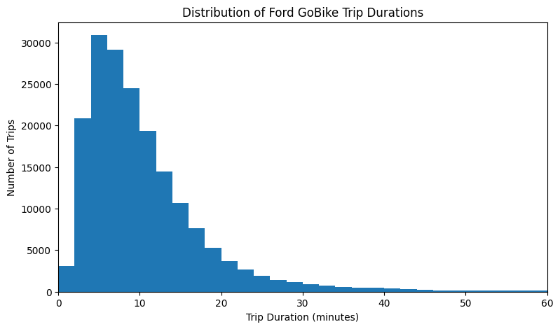

```python
# Question: What is the distribution of typical trip durations?

bins = np.arange(0, 61, 2)

plt.figure(figsize=(9, 5))
plt.hist(data=df, x='duration_min', bins=bins)
plt.xlim(0, 60)
plt.xlabel('Trip Duration (minutes)')
plt.ylabel('Number of Trips')
plt.title('Distribution of Ford GoBike Trip Durations')
plt.show()
```

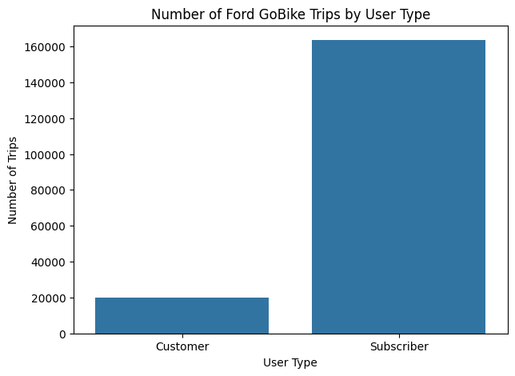

```python
# Question: What proportion of trips are made by each user type?

plt.figure(figsize=(7, 5))
sns.countplot(data=df, x='user_type')

plt.xlabel('User Type')
plt.ylabel('Number of Trips')
plt.title('Number of Ford GoBike Trips by User Type')
plt.show()
```

### Discuss the distribution(s) of your variable(s) of interest. Were there any unusual points? Did you need to perform any transformations?

Trip duration has a strongly right-skewed distribution. Most trips are relatively short, with the highest frequency occurring around 4–8 minutes, and the number of trips decreases as duration increases. The median trip duration is about 8.6 minutes, while 75% of trips last less than about 13.3 minutes. There are also unusually long trips, including a maximum duration of about 1,424 minutes. I converted duration from seconds to minutes to make the values easier to interpret and limited the histogram to 60 minutes so that the distribution of typical trips could be examined without the extreme values compressing the visualization.

### Of the features you investigated, were there any unusual distributions? Did you perform any operations on the data to tidy, adjust, or change the form of the data? If so, why did you do this?

The user type distribution is highly imbalanced. Subscribers account for the large majority of trips, while customers represent a much smaller proportion. This suggests that the Ford GoBike system was used primarily by subscribers during the period represented by the dataset. No transformation was necessary for the user_type variable because it is already stored as a categorical variable. For trip duration, I created a new duration_min variable from duration_sec to make the values easier to interpret. I also identified extreme long-duration trips, but retained them in the dataset and adjusted the visualization range rather than removing them at this stage.

## Bivariate Exploration

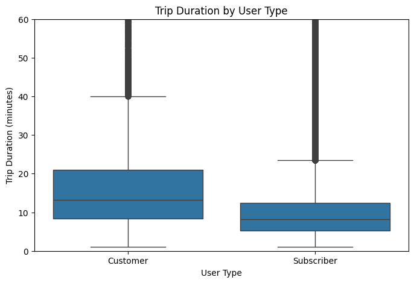

```python
# Question: Does trip duration differ between Customers and Subscribers?

plt.figure(figsize=(8, 5))

sns.boxplot(
    data=df,
    x='user_type',
    y='duration_min'
)

# Focus on typical trips so extreme durations do not compress the boxes
plt.ylim(0, 60)

plt.xlabel('User Type')
plt.ylabel('Trip Duration (minutes)')
plt.title('Trip Duration by User Type')
plt.show()
```

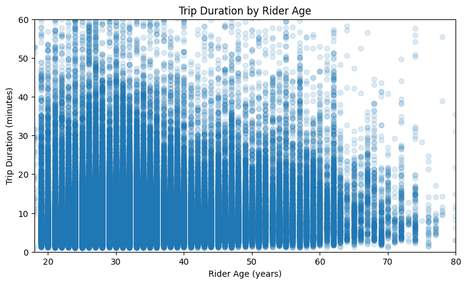

```python
# Create rider age based on the year of the dataset
df['age'] = 2019 - df['member_birth_year']

# Question: Is rider age associated with trip duration?

plt.figure(figsize=(9, 5))

plt.scatter(
    data=df,
    x='age',
    y='duration_min',
    alpha=0.15
)

plt.xlim(18, 80)
plt.ylim(0, 60)

plt.xlabel('Rider Age (years)')
plt.ylabel('Trip Duration (minutes)')
plt.title('Trip Duration by Rider Age')
plt.show()
```

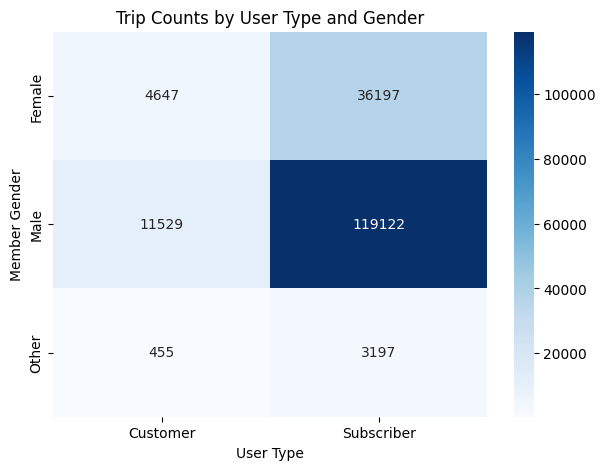

```python
# Question: How does the distribution of rider gender differ by user type?

gender_user_counts = pd.crosstab(
    df['member_gender'],
    df['user_type']
)

plt.figure(figsize=(7, 5))

sns.heatmap(
    gender_user_counts,
    annot=True,
    fmt='d',
    cmap='Blues'
)

plt.xlabel('User Type')
plt.ylabel('Member Gender')
plt.title('Trip Counts by User Type and Gender')
plt.show()
```

### Talk about some of the relationships you observed in this part of the investigation. How did the feature(s) of interest vary with other features in the dataset?

Trip duration varied noticeably by user type. Customers generally had longer trips than Subscribers, with a higher median trip duration and a wider distribution. This suggests that Customers may use the bike-sharing system differently from Subscribers. When trip duration was compared with rider age, there was no strong relationship across most of the age range. Most trips remained relatively short regardless of age, although longer trips appeared somewhat more frequently among younger riders. Transparency was used in the scatter plot to reduce the effects of overplotting.

### Did you observe any interesting relationships between the other features (not the main feature(s) of interest)?

The relationship between user type and gender showed that Subscribers made substantially more trips than Customers across all gender categories. Male riders accounted for the largest number of trips for both user types, followed by female riders, while riders categorized as Other represented the smallest group. The heatmap therefore reinforces the earlier observation that the dataset is dominated by Subscribers and also shows an imbalance in trip counts across gender categories.

## Multivariate Exploration

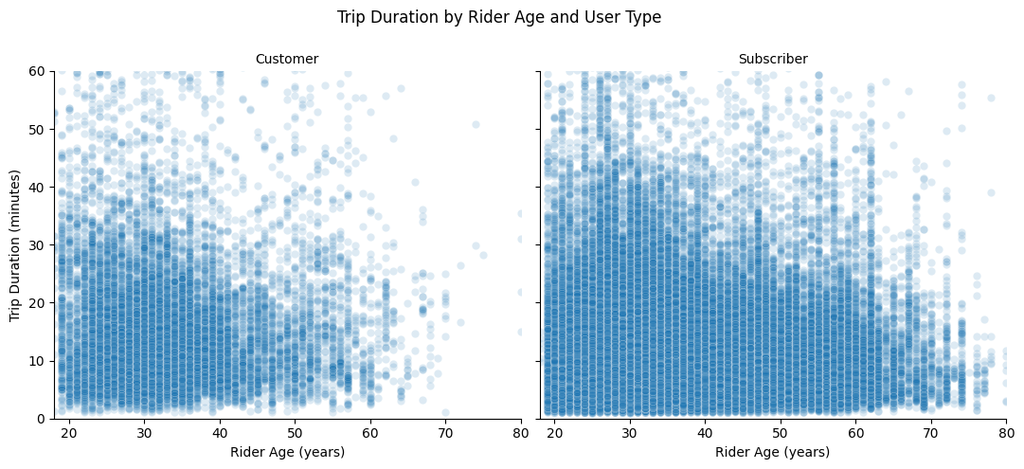

```python
# Question: How does trip duration vary with rider age across user types?

g = sns.FacetGrid(
    data=df,
    col='user_type',
    height=5,
    aspect=1.1
)

g.map_dataframe(
    sns.scatterplot,
    x='age',
    y='duration_min',
    alpha=0.15
)

g.set(
    xlim=(18, 80),
    ylim=(0, 60)
)

g.set_axis_labels('Rider Age (years)', 'Trip Duration (minutes)')
g.set_titles('{col_name}')

plt.subplots_adjust(top=0.85)
g.fig.suptitle('Trip Duration by Rider Age and User Type')

plt.show()
```

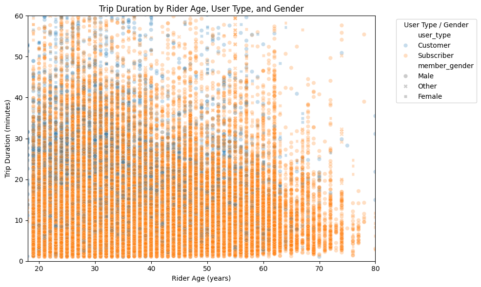

```python
# Question: How do age, trip duration, user type, and gender interact?

plt.figure(figsize=(10, 6))

sns.scatterplot(
    data=df,
    x='age',
    y='duration_min',
    hue='user_type',
    style='member_gender',
    alpha=0.25
)

plt.xlim(18, 80)
plt.ylim(0, 60)

plt.xlabel('Rider Age (years)')
plt.ylabel('Trip Duration (minutes)')
plt.title('Trip Duration by Rider Age, User Type, and Gender')

plt.legend(
    title='User Type / Gender',
    bbox_to_anchor=(1.05, 1),
    loc='upper left'
)

plt.tight_layout()
plt.show()
```

### Talk about some of the relationships you observed in this part of the investigation. Were there features that strengthened each other in terms of looking at your feature(s) of interest?

Across both Customers and Subscribers, most trips are relatively short across the full range of rider ages. There does not appear to be a strong relationship between rider age and trip duration. However, Customers show a somewhat wider spread of trip durations than Subscribers. The facet plot also makes the difference between the two user types easier to compare while controlling for rider age.

### Were there any interesting or surprising interactions between features?

When rider gender was added as another encoding, there was no clear gender-specific relationship between age and trip duration. The strongest pattern remained the difference in the number of observations between user types, with Subscribers representing the majority of trips. Across gender and user type groups, trip durations were concentrated at shorter values, while longer trips occurred less frequently. This suggests that user type is more informative for explaining differences in trip duration than either age or gender alone.

## Conclusions

### Summary of Findings

Most Ford GoBike trips were relatively short. The trip-duration distribution was strongly right-skewed, with most trips concentrated below approximately 15 minutes and a smaller number of unusually long trips. Subscribers accounted for the large majority of trips compared with Customers, indicating that the system was used primarily by Subscribers during the period represented by the dataset. Customers generally took longer trips than Subscribers and showed greater variation in trip duration. Rider age did not show a strong relationship with trip duration. Most riders across the age range tended to take relatively short trips. Male riders accounted for the largest number of recorded trips, followed by female riders and riders categorized as Other. Subscribers were the dominant user type across all gender categories. The multivariate analysis confirmed that the difference between Customers and Subscribers was more noticeable than differences associated with age or gender. User type therefore appears to be an important feature for understanding trip behavior in this dataset.

### Reflection

The exploration began by examining individual variables such as trip duration and user type, then investigated relationships between trip duration, user type, age, and gender. Trip duration was converted from seconds to minutes to improve interpretability, and visualizations of duration were limited to typical trip ranges so that extreme values would not obscure the main patterns. Extremely long trips and unusually early reported birth years were identified during the exploration and should be considered when interpreting the results. Overall, the analysis suggests that Ford GoBike usage was dominated by Subscribers taking relatively short trips, while Customers tended to make fewer but somewhat longer and more variable trips.